# Lab 5: Regression

P. Johnson, B. Rogers, L. Shaw

Wednesday, February 25, 2015

# Elementary (simple) regression part 2

- Pulling data from the internet
- Example
- Interpretation
- Mean centering
- Pleasing plots

# Let’s take a look at the publicspending.txt data.

- EX: Per capita state and local public expenditures ($)
- ECAB: Economic ability index, in which income, retail sales, and the value of output (manufactures, mineral, and agricultural) per capita are equally weighted.
- MET: Percentage of population living in standard metropolitan areas
- GROW: Percent change in population, 1950-1960
- YOUNG: Percent of population aged 5-19 years
- OLD: Percent of population over 65 years of age
- WEST: Western state (1) or not (0)
- STATE: Abbreviation of state

# Get Data, put in same directory as this file

```r
getwd()
```

```
## [1] "D:/Users/l076s857/Documents/GitHub/labstat/lab05"
```

```r
if (!file.exists("publicspending.txt")){
    lab5.url <- "http://pj.freefaculty.org/guides/stat/DataSets/PublicSpending/publicspending.txt"
    download.file(lab5.url, destfile = "publicspending.txt")
}
lab5 <- read.table("publicspending.txt", header = TRUE)
```

- We first check to see if ‘publicspending.txt’ is in our working directory
- If publicspending is not found (!fileexists), run the two line between { and }
  - assign internet url to a variable
  - download the file to working directory and call it publicspending.txt
- Read data file from working directory

```r
library(rockchalk)
```

# Look at our data

- First, we want to check the names of all of our variables

```r
head(lab5)
```

```
##    EX  ECAB  MET GROW YOUNG  OLD WEST STATE
## 1 256  85.5 19.7  6.9  29.6 11.0    0    ME
## 2 275  94.3 17.7 14.7  26.4 11.2    0    NH
## 3 327  87.0  0.0  3.7  28.5 11.2    0    VT
## 4 297 107.5 85.2 10.2  25.1 11.1    0    MA
## 5 256  94.9 86.2  1.0  25.3 10.4    0    RI
## 6 312 121.6 77.6 25.4  25.2  9.6    0    CT
```

# Oops, that capitalization problem

- Last week, the data set on Blackboard had variables in UPPER CASE.
- You can convert them all to lower case with a single command for simpler typing.

```r
colnames(lab5) <- tolower(colnames(lab5))
names(lab5)
```

```
## [1] "ex"    "ecab"  "met"   "grow"  "young" "old"   "west"  "state"
```

# Look over the data

```r
summarize(lab5)
```

```
## $numerics
##          ecab        ex     grow      met     old    west   young
## 0%    57.4000  183.0000  -7.4000   0.0000  5.4000  0.0000 24.0000
## 25%   85.4000  253.5000   6.9750  24.1000  7.9500  0.0000 26.4000
## 50%   95.3000  285.5000  14.0500  46.1500  9.4500  0.5000 28.0000
## 75%  105.1000  324.0000  22.6750  69.9750 10.4250  1.0000 29.6250
## 100% 205.0000  454.0000  77.8000  86.5000 11.9000  1.0000 32.9000
## mean  96.7542  286.6458  18.7292  46.1688  9.2125  0.5000 28.1146
## sd    22.2528   58.7948  18.8747  26.9388  1.6394  0.5053  2.1485
## var  495.1885 3456.8293 356.2562 725.6988  2.6875  0.2553  4.6162
## NA's   0.0000    0.0000   0.0000   0.0000  0.0000  0.0000  0.0000
## N     48.0000   48.0000  48.0000  48.0000 48.0000 48.0000 48.0000
##
## $factors
##            state
##  AL           : 1.000
##  AR           : 1.000
##  AZ           : 1.000
##  CA           : 1.000
##  (All Others) :44.000
##  NA's         : 0.000
##  entropy      : 5.585
##  normedEntropy: 1.000
##  N            :48.000
```

# Request covariance matrix of whole data set

- We can also get a covariance matrix and correlation matrix of all of the variables in our dataset.

```r
cov(lab5)

> cov(lab5)
Error: is.numeric(x) || is.logical(x) is not TRUE
```

```r
cov(lab5[ , 1:6])
```

```
##                ex       ecab        met       grow      young        old
## ex    3456.829344 858.098316  71.646144 449.761613 -37.037278  -2.255053
## ecab   858.098316 495.188493 245.136835 193.237961 -28.182934  -1.623245
## met     71.646144 245.136835 725.698790 205.430931 -36.248258  -1.813005
## grow   449.761613 193.237961 205.430931 356.256152  -8.292562 -12.766330
## young  -37.037278 -28.182934 -36.248258  -8.292562   4.616166  -1.848910
## old     -2.255053  -1.623245  -1.813005 -12.766330  -1.848910   2.687500
```

# And the correlation matrix

- We are not including our dichotomous variable, west

```r
cor(lab5[ , 1:6])
```

```
##                ex        ecab         met       grow      young
## ex     1.00000000  0.65586251  0.04523511  0.4052866 -0.2931969
## ecab   0.65586251  1.00000000  0.40892636  0.4600722 -0.5894680
## met    0.04523511  0.40892636  1.00000000  0.4040233 -0.6262796
## grow   0.40528659  0.46007220  0.40402333  1.0000000 -0.2044875
## young -0.29319692 -0.58946801 -0.62627957 -0.2044875  1.0000000
## old   -0.02339611 -0.04449636 -0.04105316 -0.4125823 -0.5249292
##               old
## ex    -0.02339611
## ecab  -0.04449636
## met   -0.04105316
## grow  -0.41258234
## young -0.52492921
## old    1.00000000
```

# Plot matrix of bivariate relationships

- We are not plotting our dichotomous variable, west

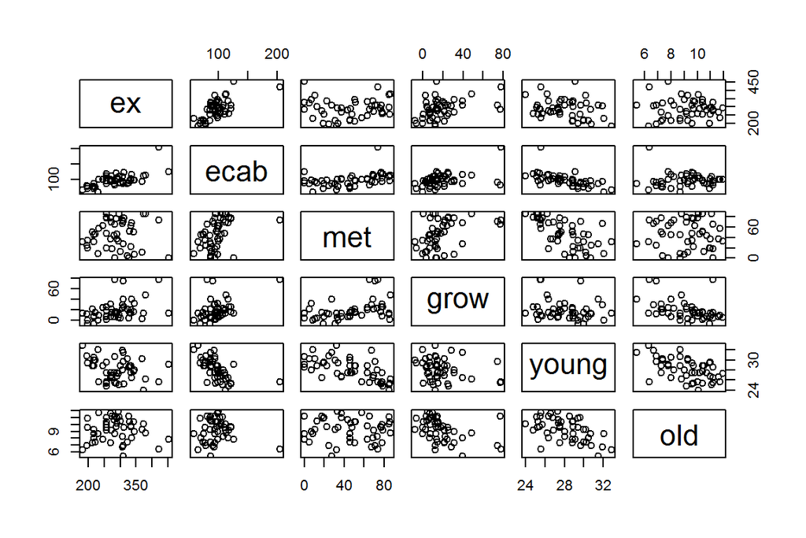

```r
plot(lab5[ , 1:6])
```

# Elementary regression example

- public expenditures regressed on economic capabilities
- Step 1. Run the regression.

```r
mod1 <-lm(ex ~ ecab, data = lab5)
```

- Step 2. Look at model summary.

```r
summary(mod1)
```

```
##
## Call:
## lm(formula = ex ~ ecab, data = lab5)
##
## Residuals:
##    Min     1Q Median     3Q    Max
## -66.29 -39.78  -7.83  35.29 117.02
##
## Coefficients:
##             Estimate Std. Error t value Pr(>|t|)
## (Intercept) 118.9832    29.1802   4.078 0.000179 ***
## ecab          1.7329     0.2941   5.893 4.19e-07 ***
## ---
## Signif. codes:  0 '***' 0.001 '**' 0.01 '*' 0.05 '.' 0.1 ' ' 1
##
## Residual standard error: 44.86 on 46 degrees of freedom
## Multiple R-squared:  0.4302, Adjusted R-squared:  0.4178
## F-statistic: 34.72 on 1 and 46 DF,  p-value: 4.193e-07
```

# Look at vcov

```r
vcov(mod1)
```

```
##             (Intercept)        ecab
## (Intercept)   851.48358 -8.36711041
## ecab           -8.36711  0.08647804
```

- You can use vcov info to compute model standard errors.

```r
sqrt(diag(vcov(mod1)))
```

```
## (Intercept)        ecab
##  29.1801916   0.2940715
```

# Model interpretation

- The average public expenditure (ex) is 118.98 when there is 0 economic capabilities (ecab).
- Does this interpretation make sense?
- What is public expenditure for average economic capabilities?

```r
mean(lab5$ecab)
```

```
## [1] 96.75417
```

```r
# b0 + b1ecab_at_mean
118.9832 + 1.7329*96.75417
```

```
## [1] 286.6485
```

# Put centered predictor into regression

- We are centering at the mean, but we can choose any other value that would aid interpretation.
  - If we were studying students in grades 1-5, an intercept when grade is 0 makes little sense.
  - We could recenter on the average grade, 3, so the intercept would be the average for 3rd graders (grade - mean(grade)).
  - We could ‘recenter’ grade so that intercept would be the average in grade 1 (grade - 1).
- We could also put the variable on standard, normal scale with mean = 0 and variance = 1.
  - This is based on the z-scale.
  - The regression coefficient is a standardized coefficient.

# Use scale to ‘recenter’

- First list the variable you want to change.
- If you enter nothing else in the function, the variable will be standardized with mean = 0, variance = 1.
- Setting ‘scale = FALSE’ will not divide the term by its variance.
- If you want to center by something other than the mean, change ‘center =’ to your number.

```r
lab5$ecabmc <- scale(lab5$ecab,  center = TRUE, scale = FALSE)
```